# Chapter 3 - The Forecaster’s Toolbox

Greg Foletta

2020-06-17

```r
library(tidyverse)
library(forecast)
library(fma)
library(magrittr)
library(fpp)
library(fpp2)
library(tsibble)
library(lubridate)
```

# Simple Forecasting Methods

Some methods are extremely simple yet surprisingly effective. The following methods can be considered the benchmark against which other models will be tested.

## Average Method

Here, the forecasts of all future values are equal to the average (mean) of the historical data.

$$\hat{y}_{T + h|T} = \bar{y} = (y_1 + \ldots + y_T)/T$$

```r
dj %>% meanf(5)
```

```
##     Point Forecast    Lo 80  Hi 80    Lo 95    Hi 95
## 293       3754.507 3618.814 3890.2 3546.589 3962.425
## 294       3754.507 3618.814 3890.2 3546.589 3962.425
## 295       3754.507 3618.814 3890.2 3546.589 3962.425
## 296       3754.507 3618.814 3890.2 3546.589 3962.425
## 297       3754.507 3618.814 3890.2 3546.589 3962.425
```

## Naive Method

For naive forecasts, we simply set all forecasts to be the value of the last observation:

$$\bar{y}_{T + h|T} = y_T$$

```r
dj %>% naive(2)
```

```
##     Point Forecast    Lo 80    Hi 80    Lo 95    Hi 95
## 293           3855 3826.155 3883.845 3810.886 3899.114
## 294           3855 3814.207 3895.793 3792.613 3917.387
```

```r
dj %>% rwf(2)
```

```
##     Point Forecast    Lo 80    Hi 80    Lo 95    Hi 95
## 293           3855 3826.155 3883.845 3810.886 3899.114
## 294           3855 3814.207 3895.793 3792.613 3917.387
```

Because a naive forecast is optimal when data follow a random walk, these are also called **random walk forecasts**.

## Seasonal Naive Method

A similar method is useful for highly seasonal data. Each forecast is set to bethe last observed value from the same season of the year.

$$\bar{y}_{T + h|T} = y_{T + h - m(k+1)}$$

Where $m$ is the seasonal period, and $k$ is the integer part of $(h - 1)/m$, i.e. the number of complete years in the forecast period prior to time $T + h$.

e.g. for monthly data, the forecast for all future February values is equal to the last observed February value.

```r
dj %>% snaive(2)
```

```
##     Point Forecast    Lo 80    Hi 80    Lo 95    Hi 95
## 293           3855 3826.155 3883.845 3810.886 3899.114
## 294           3855 3814.207 3895.793 3792.613 3917.387
```

## Drift Method

A variation on the naive method is to allow the forecasts to increase or decrease over time, where the amount of change over time is called **drift**. This is set to the average change in the historical data.

$$\bar{y}_{T + h|T} = y_T + \frac{h}{T-1} \sum_{t=2}^T (y_y - y_{t-1} ) \\
= y_T + h \bigg( \frac{ y_T - y_1 }{ T - 1 } \bigg)$$

This is equivalent between drawing a line between the first and last observations and extrapolating this into the future.

```r
elec %>% rwf(3, drift = TRUE)
```

```
##          Point Forecast    Lo 80    Hi 80    Lo 95   Hi 95
## Sep 1995       14484.80 13895.27 15074.33 13583.19 15386.4
## Oct 1995       14512.59 13677.99 15347.19 13236.18 15789.0
## Nov 1995       14540.39 13517.14 15563.63 12975.47 16105.3
```

# Examples

Applying the first three methods to the quarterly beer production

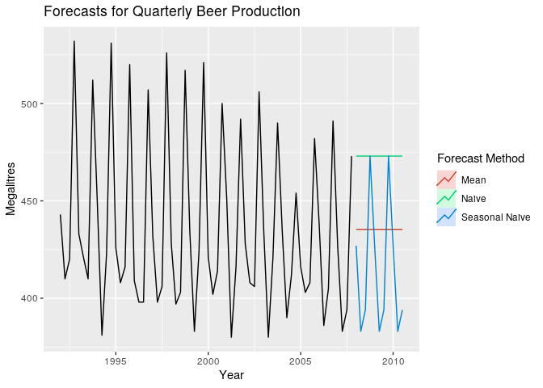

```r
ausbeer %>%
    window(., start = 1992, end = c(2007, 4)) %>% {
    autoplot(.) +
    autolayer(meanf(., h=11), PI = FALSE, series = 'Mean') +
    autolayer(naive(., h=11), PI = FALSE, series = 'Naive') +
    autolayer(snaive(., h=11), PI = FALSE, series = 'Seasonal Naive')
} +
    labs(
        x = 'Year',
        y = 'Megalitres',
        title = 'Forecasts for Quarterly Beer Production',
        colour = 'Forecast Method'
    )
```

Non-seasonal methods applied to 200 days of Google stock prices:

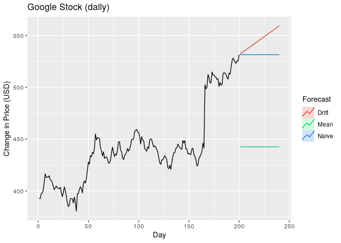

```r
goog200 %>% {
    autoplot(.) +
    autolayer(meanf(., 40), PI = FALSE, series = 'Mean') +
    autolayer(rwf(., 40), PI = FALSE, series = 'Naive') +
    autolayer(rwf(., 40, drift = TRUE), PI = FALSE, series = 'Drift') +
    labs(
        x = 'Day',
        y = 'Change in Price (USD)',
        colour = 'Forecast',
        title = 'Google Stock (daily)'
    )
}
```

Sometimes these methods are the best forecasting method available, but mainly they are used as a benchmark - i.e. if a more complex forecasting method can’t perform better than these, it shouldn’t be considered.

# Transformations and Adjustments

Adjusting the data can sometimes lead to simpler forecasting tasks. The purpose of transformation is to simplify the patterns in historical data by removing known sources of variation, or by making the pattern more consistent across the whole data set.

## Calendar Adjustments

Some variation may be due to calendar effects and it can be much easier to remove this variation before fitting a forecasting model.

For example studying milk production on a farm, there is variation simply because the numnber of days in a month is not the same. The `monthdays()` function computes the number of days in each month or quarter.

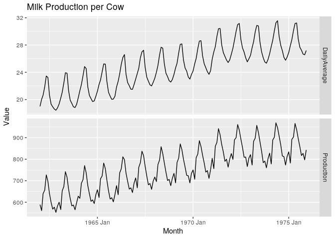

```r
milk %>%
    as_tsibble() %>%
    rename(Month = index, Production = value) %>%
    mutate(DailyAverage = Production / days_in_month(as_date(Month))) %>%
    gather(Metric, Value, c('Production', 'DailyAverage')) %>%
    ggplot() +
    geom_line(aes(Month, Value)) +
    facet_grid(rows = vars(Metric), scales = 'free') +
    labs(
        x = 'Month',
        y = 'Value',
        title = 'Milk Production per Cow'
    )
```

We can see that the pattern in the daily average is much simpler than the raw production values. By removing the variation due to the different month lengths, we’ve created a simpler pattern which should be easier to forecast.

This adjustment is pertinent for sales data when the number of trading days in the month varies. In this case the number of sales per trading day can be modelled instead of total sales for the month.